# Generalised Linear Modelling

Matthew Talluto

05.05.2022

# More linear models

- Our linear model used a single x-variable: $\mathbb{E}(y) = a + bx$
- It is trivial to add additional predictors to a model: $\mathbb{E}(y) = a + b_1x_1 + b_2x_2 + \dots + b_nx_n$

# More linear models

- Our linear model used a single x-variable: $\mathbb{E}(y) = a + bx$
- It is trivial to add additional predictors to a model: $\mathbb{E}(y) = a + b_1x_1 + b_2x_2 + \dots + b_nx_n$
- You can also easily add a “curve” in the relationship between x and y by transforming x:

$$\mathbb{E}(y) = a + b_1x + b_2x^2$$

- Use caution: curves can predict silly things
  - does it make sense that height decreases after a certain weight?
- This is still a linear model. Why?

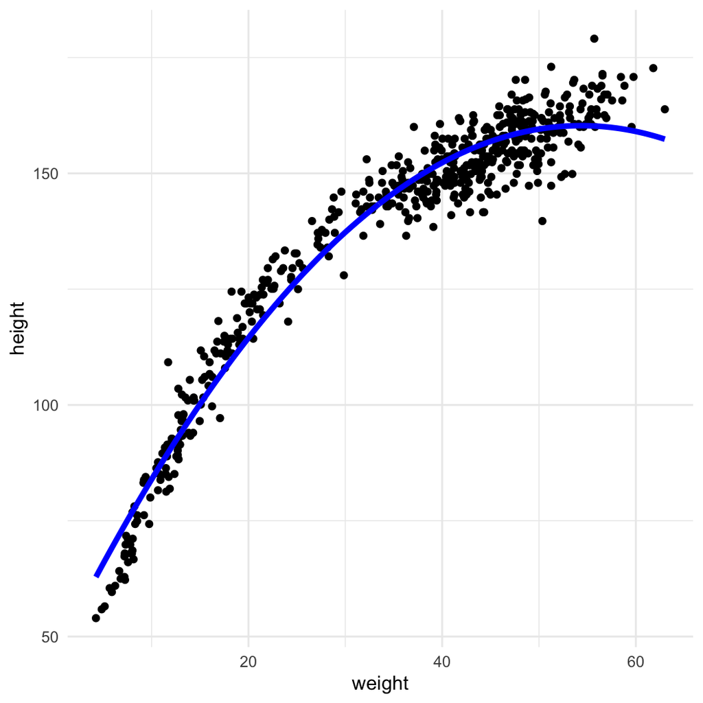

# Categorical Variables

- Perhaps we want to model a categorical variable based on age.

```r
Howell1[, age_c := factor(ifelse(age <= 12, "child",
          ifelse(age > 22, "adult", "young")))]
Howell1
```

```
##       height    weight age male age_c
##   1: 151.765 47.825606  63    1 adult
##   2: 139.700 36.485807  63    0 adult
##   3: 136.525 31.864838  65    0 adult
##   4: 156.845 53.041914  41    1 adult
##   5: 145.415 41.276872  51    0 adult
##  ---
## 540: 145.415 31.127751  17    1 young
## 541: 162.560 52.163080  31    1 adult
## 542: 156.210 54.062497  21    0 young
## 543:  71.120  8.051258   0    1 child
## 544: 158.750 52.531624  68    1 adult
```

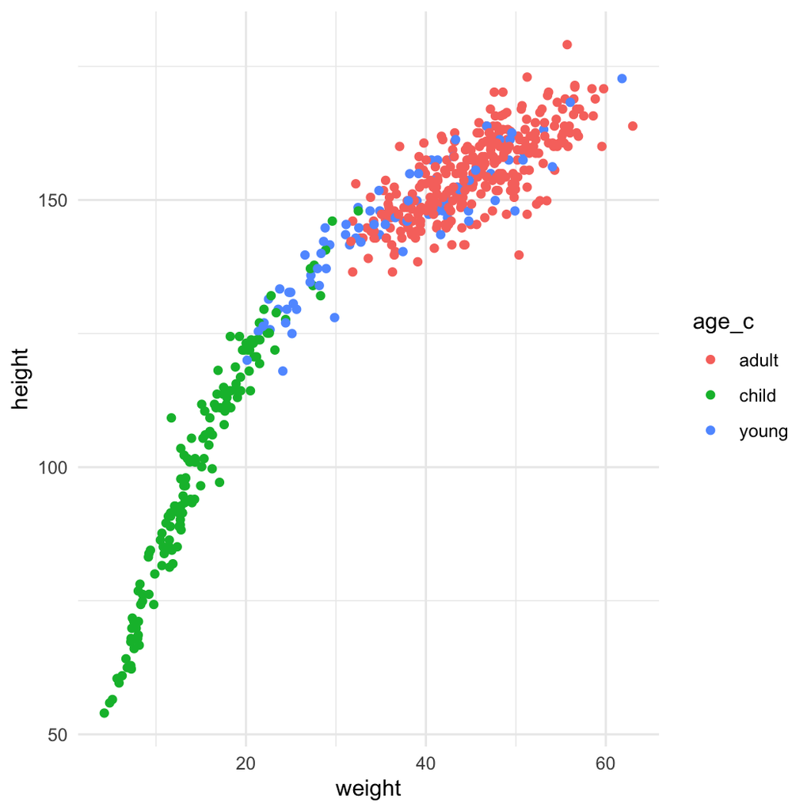

# Categorical Variables

- Perhaps we want to model a categorical variable based on age.
- `lm` and other tools often handle this automatically.
- To reproduce what they do, for $k$ categories we need to use $k-1$ *dummy variables* with 0-1 coding
- Add parameters to our linear model for each dummy variable

```r
Howell1[, ac_child := as.integer(age_c == "child")]
Howell1[, ac_young := as.integer(age_c == "young")]
Howell1
```

```
##       height    weight age male age_c ac_child ac_young
##   1: 151.765 47.825606  63    1 adult        0        0
##   2: 139.700 36.485807  63    0 adult        0        0
##   3: 136.525 31.864838  65    0 adult        0        0
##   4: 156.845 53.041914  41    1 adult        0        0
##   5: 145.415 41.276872  51    0 adult        0        0
##  ---
## 540: 145.415 31.127751  17    1 young        0        1
## 541: 162.560 52.163080  31    1 adult        0        0
## 542: 156.210 54.062497  21    0 young        0        1
## 543:  71.120  8.051258   0    1 child        1        0
## 544: 158.750 52.531624  68    1 adult        0        0
```

```r
## equivalent of lm(height ~ age_cat + weight)
log_liklihood1 = function(params, data) {
  mu = params['a'] + params['b_child']*data[['ac_child']] +
    params['b_young']*data[['ac_young']] +
    params['b_weight']*data[['weight']]
  sum(dnorm(data[['height']], mu, params['s'], log=TRUE))
}

## equivalent of lm(height ~ age_cat * weight)
log_liklihood2 = function(params, data) {
  mu = params['a'] + params['b_child']*data[['ac_child']] +
    params['b_young']*data[['ac_young']] +
    params['b_weight']*data[['weight']] +
    params['b_cw']*data[['ac_child']]*data[['weight']] +
    params['b_yw']*data[['ac_young']]*data[['weight']]
  sum(dnorm(data[['height']], mu, params['s'], log=TRUE))
}
```

# A general statement for mu

- Model statements, function signatures get ugly fast
- We can simplify the notation (and the computation) a lot using matrices
- $\mathbf{X}$ is now a **matrix** with $n$ rows (one per data point) and $k$ columns (one per predictor)
- This includes transformations; if we want $weight^2$ in our model, we add a column in $\mathbf{X}$ for it
- $\mathbf{B}$ is a parameter vector of length $k$, one parameter to go with each x-variable

$$\mathbb{E}(y) = a + \mathbf{B}\mathbf{X}$$

# A general statement for mu

- Model statements, function signatures get ugly fast
- We can simplify the notation (and the computation) a lot using matrices
- $\mathbf{X}$ is now a **matrix** with $n$ rows (one per data point) and $k$ columns (one per predictor)
- This includes transformations; if we want $weight^2$ in our model, we add a column in $\mathbf{X}$ for it
- $\mathbf{B}$ is a parameter vector of length $k$, one parameter to go with each x-variable
- This likelihood is now general; can use it with any $X$, any set of predictors

```r
log_liklihood3 = function(a, B, s, y, X) {
  mu = a + X %*% B  ## %*% is matrix multiplication, returns a vector length n
  sum(dnorm(height, mu, s, log=TRUE))
}
```

# Changing the distribution of y

- What if $y$ doesn’t come from a normal distribution?
- There is nothing saying this is fixed
- For some generic distribution $\mathcal{D}$, we can say:

$$\begin{aligned}
\mathbb{E}(y) & = a + \mathbf{B}\mathbf{X} \\
y & \sim \mathcal{D}(\mathbb{E}(y), ...)
\end{aligned}$$

# Example: Tree mortality as a function of temperature

- We already modelled tree mortality using a binomial likelihood. It’s easy to add a linear model

```r
tsuga = readRDS("exercises/data/tsuga.rds")
tsuga[, 4:8]
```

```
##       born died n annual_mean_temp tot_annual_pp
##    1:    1    0 0         3.414667     1085.2000
##    2:    0    3 5         3.849333     1003.0000
##    3:    3    0 6         3.452000     1076.1333
##    4:    1    0 3         3.620000     1099.4000
##    5:    0    4 4         4.596000      989.4667
##   ---
## 1538:    0    1 1         4.329333     1234.0000
## 1539:    1    0 3         4.134000     1191.0000
## 1540:    0    1 4         4.372000     1207.2667
## 1541:    0    1 2         4.247333     1220.2667
## 1542:    0    1 4         4.283333     1200.9333
```

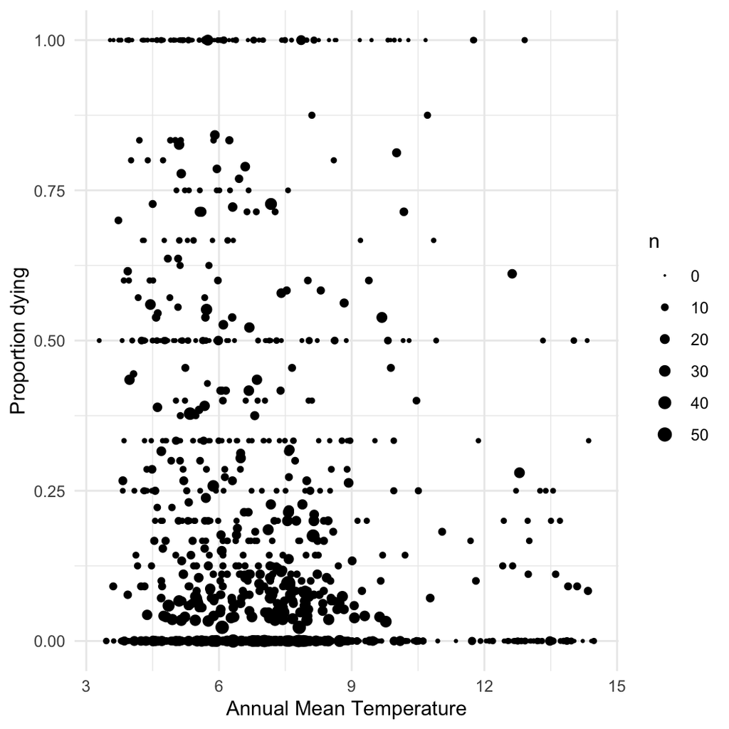

# Tree mortality log posterior

$$\begin{aligned}
\mathbb{E}(died/n) &= p = a + bT \\
died & \sim \mathrm{Binomial}(p, n)
\end{aligned}$$

```r
log_posterior = function(params, data) {
  # parameters for the regression model
  a = params['a']
  b = params['b']
  n = data[['n']]
  died = data[['died']]
  temperature = data[['annual_mean_temp']]

  # the probability of death changes with temperature
  p = a + b*temperature

  # liklihood
  logpr = sum(dbinom(died, n, p, log=TRUE))

  # priors
  logpr = logpr + dnorm(a, 0, 20, log=TRUE) + dnorm(b, 0, 5, log=TRUE)
  logpr
}
```

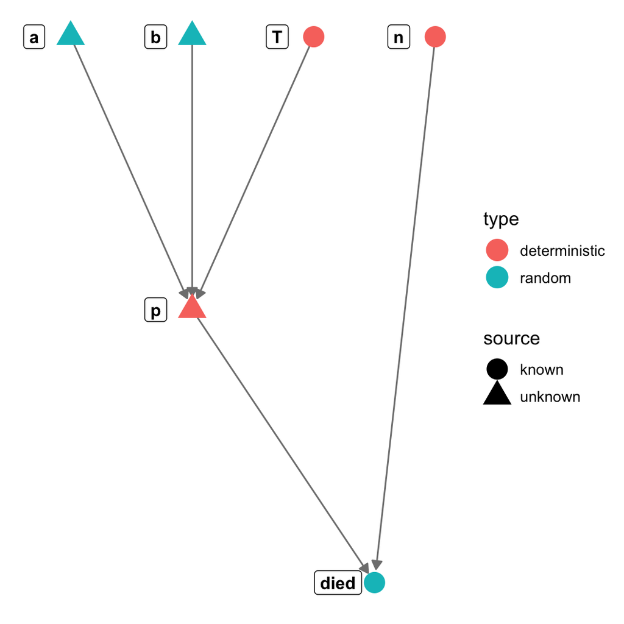